# Optimal Treatment Analysis

## Outcome Variable

**Outcome Variable:** whz

## Predictor Variables

**Intervention Variable:** vagbrth

**Adjustment Set:**

- arm
- sex
- W_mage
- meducyrs
- feducyrs
- W_mhtcm
- single
- brthmon
- W_parity
- delta_W_mage
- delta_meducyrs
- delta_feducyrs
- delta_W_mhtcm
- delta_single
- delta_brthmon
- delta_W_parity

## Stratifying Variables

The analysis was stratified on these variable(s):

- agecat
- studyid
- country

## Data Summary

| agecat | studyid | country | vagbrth | n_cell | n |
| --- | --- | --- | --- | --- | --- |
| Birth | ki1000108-CMC-V-BCS-2002 | INDIA | 0 | 10 | 88 |
| Birth | ki1000108-CMC-V-BCS-2002 | INDIA | 1 | 78 | 88 |
| Birth | ki1000108-IRC | INDIA | 0 | 66 | 343 |
| Birth | ki1000108-IRC | INDIA | 1 | 277 | 343 |
| Birth | ki1017093c-NIH-Crypto | BANGLADESH | 0 | 1 | 17 |
| Birth | ki1017093c-NIH-Crypto | BANGLADESH | 1 | 16 | 17 |
| Birth | ki1119695-PROBIT | BELARUS | 0 | 1593 | 13824 |
| Birth | ki1119695-PROBIT | BELARUS | 1 | 12231 | 13824 |
| Birth | ki1126311-ZVITAMBO | ZIMBABWE | 0 | 1099 | 12813 |
| Birth | ki1126311-ZVITAMBO | ZIMBABWE | 1 | 11714 | 12813 |
| Birth | kiGH5241-JiVitA-3 | BANGLADESH | 0 | 2 | 15689 |
| Birth | kiGH5241-JiVitA-3 | BANGLADESH | 1 | 15687 | 15689 |
| Birth | kiGH5241-JiVitA-4 | BANGLADESH | 0 | 1 | 683 |
| Birth | kiGH5241-JiVitA-4 | BANGLADESH | 1 | 682 | 683 |
| 6 months | ki1000108-CMC-V-BCS-2002 | INDIA | 0 | 25 | 368 |
| 6 months | ki1000108-CMC-V-BCS-2002 | INDIA | 1 | 343 | 368 |
| 6 months | ki1000108-IRC | INDIA | 0 | 68 | 408 |
| 6 months | ki1000108-IRC | INDIA | 1 | 340 | 408 |
| 6 months | ki1017093b-PROVIDE | BANGLADESH | 0 | 134 | 582 |
| 6 months | ki1017093b-PROVIDE | BANGLADESH | 1 | 448 | 582 |
| 6 months | ki1017093c-NIH-Crypto | BANGLADESH | 0 | 187 | 457 |
| 6 months | ki1017093c-NIH-Crypto | BANGLADESH | 1 | 270 | 457 |
| 6 months | ki1066203-TanzaniaChild2 | TANZANIA, UNITED REPUBLIC OF | 0 | 189 | 2004 |
| 6 months | ki1066203-TanzaniaChild2 | TANZANIA, UNITED REPUBLIC OF | 1 | 1815 | 2004 |
| 6 months | ki1119695-PROBIT | BELARUS | 0 | 1798 | 15757 |
| 6 months | ki1119695-PROBIT | BELARUS | 1 | 13959 | 15757 |
| 6 months | ki1126311-ZVITAMBO | ZIMBABWE | 0 | 706 | 8197 |
| 6 months | ki1126311-ZVITAMBO | ZIMBABWE | 1 | 7491 | 8197 |
| 6 months | kiGH5241-JiVitA-3 | BANGLADESH | 0 | 1075 | 16705 |
| 6 months | kiGH5241-JiVitA-3 | BANGLADESH | 1 | 15630 | 16705 |
| 6 months | kiGH5241-JiVitA-4 | BANGLADESH | 0 | 337 | 4056 |
| 6 months | kiGH5241-JiVitA-4 | BANGLADESH | 1 | 3719 | 4056 |
| 24 months | ki1000108-CMC-V-BCS-2002 | INDIA | 0 | 25 | 372 |
| 24 months | ki1000108-CMC-V-BCS-2002 | INDIA | 1 | 347 | 372 |
| 24 months | ki1000108-IRC | INDIA | 0 | 69 | 409 |
| 24 months | ki1000108-IRC | INDIA | 1 | 340 | 409 |
| 24 months | ki1017093b-PROVIDE | BANGLADESH | 0 | 137 | 578 |
| 24 months | ki1017093b-PROVIDE | BANGLADESH | 1 | 441 | 578 |
| 24 months | ki1017093c-NIH-Crypto | BANGLADESH | 0 | 99 | 260 |
| 24 months | ki1017093c-NIH-Crypto | BANGLADESH | 1 | 161 | 260 |
| 24 months | ki1066203-TanzaniaChild2 | TANZANIA, UNITED REPUBLIC OF | 0 | 2 | 6 |
| 24 months | ki1066203-TanzaniaChild2 | TANZANIA, UNITED REPUBLIC OF | 1 | 4 | 6 |
| 24 months | ki1119695-PROBIT | BELARUS | 0 | 463 | 3971 |
| 24 months | ki1119695-PROBIT | BELARUS | 1 | 3508 | 3971 |
| 24 months | ki1126311-ZVITAMBO | ZIMBABWE | 0 | 28 | 417 |
| 24 months | ki1126311-ZVITAMBO | ZIMBABWE | 1 | 389 | 417 |
| 24 months | kiGH5241-JiVitA-3 | BANGLADESH | 0 | 475 | 8555 |
| 24 months | kiGH5241-JiVitA-3 | BANGLADESH | 1 | 8080 | 8555 |
| 24 months | kiGH5241-JiVitA-4 | BANGLADESH | 0 | 323 | 4008 |
| 24 months | kiGH5241-JiVitA-4 | BANGLADESH | 1 | 3685 | 4008 |

The following strata were considered:

- agecat: 24 months, studyid: ki1000108-CMC-V-BCS-2002, country: INDIA
- agecat: 24 months, studyid: ki1000108-IRC, country: INDIA
- agecat: 24 months, studyid: ki1017093b-PROVIDE, country: BANGLADESH
- agecat: 24 months, studyid: ki1017093c-NIH-Crypto, country: BANGLADESH
- agecat: 24 months, studyid: ki1066203-TanzaniaChild2, country: TANZANIA, UNITED REPUBLIC OF
- agecat: 24 months, studyid: ki1119695-PROBIT, country: BELARUS
- agecat: 24 months, studyid: ki1126311-ZVITAMBO, country: ZIMBABWE
- agecat: 24 months, studyid: kiGH5241-JiVitA-3, country: BANGLADESH
- agecat: 24 months, studyid: kiGH5241-JiVitA-4, country: BANGLADESH
- agecat: 6 months, studyid: ki1000108-CMC-V-BCS-2002, country: INDIA
- agecat: 6 months, studyid: ki1000108-IRC, country: INDIA
- agecat: 6 months, studyid: ki1017093b-PROVIDE, country: BANGLADESH
- agecat: 6 months, studyid: ki1017093c-NIH-Crypto, country: BANGLADESH
- agecat: 6 months, studyid: ki1066203-TanzaniaChild2, country: TANZANIA, UNITED REPUBLIC OF
- agecat: 6 months, studyid: ki1119695-PROBIT, country: BELARUS
- agecat: 6 months, studyid: ki1126311-ZVITAMBO, country: ZIMBABWE
- agecat: 6 months, studyid: kiGH5241-JiVitA-3, country: BANGLADESH
- agecat: 6 months, studyid: kiGH5241-JiVitA-4, country: BANGLADESH
- agecat: Birth, studyid: ki1000108-CMC-V-BCS-2002, country: INDIA
- agecat: Birth, studyid: ki1000108-IRC, country: INDIA
- agecat: Birth, studyid: ki1017093c-NIH-Crypto, country: BANGLADESH
- agecat: Birth, studyid: ki1119695-PROBIT, country: BELARUS
- agecat: Birth, studyid: ki1126311-ZVITAMBO, country: ZIMBABWE
- agecat: Birth, studyid: kiGH5241-JiVitA-3, country: BANGLADESH
- agecat: Birth, studyid: kiGH5241-JiVitA-4, country: BANGLADESH

### Dropped Strata

Some strata were dropped due to rare outcomes:

- agecat: Birth, studyid: ki1017093c-NIH-Crypto, country: BANGLADESH
- agecat: Birth, studyid: kiGH5241-JiVitA-3, country: BANGLADESH
- agecat: Birth, studyid: kiGH5241-JiVitA-4, country: BANGLADESH
- agecat: 24 months, studyid: ki1066203-TanzaniaChild2, country: TANZANIA, UNITED REPUBLIC OF

## Methods Detail

We’re interested in the causal parameters $E[Y_a]$ for all values of $a \in \mathcal{A}$. These parameters represent the mean outcome if, possibly contrary to fact, we intervened to set all units to have $A=a$. Under the randomization and positivity assumptions, these are identified by the statistical parameters $\psi_a=E_W[E_{Y|A,W}(Y|A=a,W)]$. In addition, we’re interested in the mean of $Y$, $E[Y]$ under no intervention (the observed mean). We will estimate these parameters by using SuperLearner to fit the relevant likelihood factors – $E_{Y|A,W}(Y|A=a,W)$ and $p(A=a|W)$, and then updating our likelihood fit using a joint TMLE.

For unadjusted analyses ($W=\{\}$), initial likelihoods were estimated using Lrnr_glm to estimate the simple $E(Y|A)$ and Lrnr_mean to estimate $p(A)$. For adjusted analyses, a small library containing Lrnr_glmnet, Lrnr_xgboost, and Lrnr_mean was used.

Having estimated these parameters, we will then use the delta method to estimate relative risks and attributable risks relative to a prespecified baseline level of $A$.

# Results Detail

## Results Plots

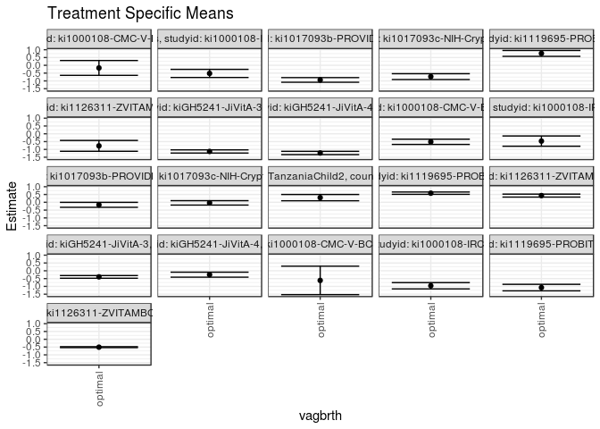

## Results Table

### Parameter: TSM

| agecat | studyid | country | intervention_level | baseline_level | estimate | ci_lower | ci_upper |
| --- | --- | --- | --- | --- | --- | --- | --- |
| Birth | ki1000108-CMC-V-BCS-2002 | INDIA | optimal | observed | -0.6175276 | -1.5296085 | 0.2945533 |
| Birth | ki1000108-IRC | INDIA | optimal | observed | -0.9590904 | -1.1602763 | -0.7579045 |
| Birth | ki1119695-PROBIT | BELARUS | optimal | observed | -1.0772437 | -1.2858667 | -0.8686208 |
| Birth | ki1126311-ZVITAMBO | ZIMBABWE | optimal | observed | -0.5066941 | -0.5357089 | -0.4776794 |
| 6 months | ki1000108-CMC-V-BCS-2002 | INDIA | optimal | observed | -0.5134311 | -0.6816019 | -0.3452603 |
| 6 months | ki1000108-IRC | INDIA | optimal | observed | -0.4677844 | -0.7960680 | -0.1395008 |
| 6 months | ki1017093b-PROVIDE | BANGLADESH | optimal | observed | -0.1628515 | -0.3222452 | -0.0034577 |
| 6 months | ki1017093c-NIH-Crypto | BANGLADESH | optimal | observed | -0.0369394 | -0.1771287 | 0.1032499 |
| 6 months | ki1066203-TanzaniaChild2 | TANZANIA, UNITED REPUBLIC OF | optimal | observed | 0.2996518 | 0.0981208 | 0.5011828 |
| 6 months | ki1119695-PROBIT | BELARUS | optimal | observed | 0.5847261 | 0.5094677 | 0.6599846 |
| 6 months | ki1126311-ZVITAMBO | ZIMBABWE | optimal | observed | 0.4294200 | 0.3348019 | 0.5240380 |
| 6 months | kiGH5241-JiVitA-3 | BANGLADESH | optimal | observed | -0.3905438 | -0.4761493 | -0.3049383 |
| 6 months | kiGH5241-JiVitA-4 | BANGLADESH | optimal | observed | -0.2497706 | -0.4093487 | -0.0901924 |
| 24 months | ki1000108-CMC-V-BCS-2002 | INDIA | optimal | observed | -0.1684788 | -0.6442219 | 0.3072643 |
| 24 months | ki1000108-IRC | INDIA | optimal | observed | -0.5192213 | -0.7796655 | -0.2587771 |
| 24 months | ki1017093b-PROVIDE | BANGLADESH | optimal | observed | -0.9373709 | -1.0865428 | -0.7881990 |
| 24 months | ki1017093c-NIH-Crypto | BANGLADESH | optimal | observed | -0.7238290 | -0.9096887 | -0.5379692 |
| 24 months | ki1119695-PROBIT | BELARUS | optimal | observed | 0.7629115 | 0.5743138 | 0.9515091 |
| 24 months | ki1126311-ZVITAMBO | ZIMBABWE | optimal | observed | -0.7734262 | -1.1209573 | -0.4258951 |
| 24 months | kiGH5241-JiVitA-3 | BANGLADESH | optimal | observed | -1.1313626 | -1.2328097 | -1.0299155 |
| 24 months | kiGH5241-JiVitA-4 | BANGLADESH | optimal | observed | -1.2294931 | -1.3342009 | -1.1247853 |

### Parameter: E(Y)

| agecat | studyid | country | intervention_level | baseline_level | estimate | ci_lower | ci_upper |
| --- | --- | --- | --- | --- | --- | --- | --- |
| Birth | ki1000108-CMC-V-BCS-2002 | INDIA | observed | observed | -0.6275000 | -0.9746292 | -0.2803708 |
| Birth | ki1000108-IRC | INDIA | observed | observed | -1.0105831 | -1.1973019 | -0.8238643 |
| Birth | ki1119695-PROBIT | BELARUS | observed | observed | -1.1463469 | -1.3562674 | -0.9364264 |
| Birth | ki1126311-ZVITAMBO | ZIMBABWE | observed | observed | -0.5165387 | -0.5425056 | -0.4905717 |
| 6 months | ki1000108-CMC-V-BCS-2002 | INDIA | observed | observed | -0.5026766 | -0.6536848 | -0.3516685 |
| 6 months | ki1000108-IRC | INDIA | observed | observed | -0.5989297 | -0.7344491 | -0.4634104 |
| 6 months | ki1017093b-PROVIDE | BANGLADESH | observed | observed | -0.2083706 | -0.2927992 | -0.1239419 |
| 6 months | ki1017093c-NIH-Crypto | BANGLADESH | observed | observed | 0.0515536 | -0.0469240 | 0.1500313 |
| 6 months | ki1066203-TanzaniaChild2 | TANZANIA, UNITED REPUBLIC OF | observed | observed | 0.0769382 | 0.0241090 | 0.1297674 |
| 6 months | ki1119695-PROBIT | BELARUS | observed | observed | 0.5789633 | 0.5190130 | 0.6389137 |
| 6 months | ki1126311-ZVITAMBO | ZIMBABWE | observed | observed | 0.3058247 | 0.2796439 | 0.3320055 |
| 6 months | kiGH5241-JiVitA-3 | BANGLADESH | observed | observed | -0.5935070 | -0.6130727 | -0.5739413 |
| 6 months | kiGH5241-JiVitA-4 | BANGLADESH | observed | observed | -0.3758037 | -0.4184544 | -0.3331531 |
| 24 months | ki1000108-CMC-V-BCS-2002 | INDIA | observed | observed | -0.5571505 | -0.6585247 | -0.4557763 |
| 24 months | ki1000108-IRC | INDIA | observed | observed | -0.7458150 | -0.8368180 | -0.6548120 |
| 24 months | ki1017093b-PROVIDE | BANGLADESH | observed | observed | -0.8879412 | -0.9708680 | -0.8050144 |
| 24 months | ki1017093c-NIH-Crypto | BANGLADESH | observed | observed | -0.8343077 | -0.9482310 | -0.7203844 |
| 24 months | ki1119695-PROBIT | BELARUS | observed | observed | 0.6863435 | 0.5745700 | 0.7981170 |
| 24 months | ki1126311-ZVITAMBO | ZIMBABWE | observed | observed | -1.1870743 | -1.2881393 | -1.0860094 |
| 24 months | kiGH5241-JiVitA-3 | BANGLADESH | observed | observed | -1.2983928 | -1.3216893 | -1.2750962 |
| 24 months | kiGH5241-JiVitA-4 | BANGLADESH | observed | observed | -1.2433658 | -1.2774681 | -1.2092634 |

### Parameter: PAR

| agecat | studyid | country | intervention_level | baseline_level | estimate | ci_lower | ci_upper |
| --- | --- | --- | --- | --- | --- | --- | --- |
| Birth | ki1000108-CMC-V-BCS-2002 | INDIA | optimal | observed | -0.0099724 | -0.8577298 | 0.8377851 |
| Birth | ki1000108-IRC | INDIA | optimal | observed | -0.0514927 | -0.1523798 | 0.0493945 |
| Birth | ki1119695-PROBIT | BELARUS | optimal | observed | -0.0691032 | -0.1641200 | 0.0259136 |
| Birth | ki1126311-ZVITAMBO | ZIMBABWE | optimal | observed | -0.0098445 | -0.0226230 | 0.0029339 |
| 6 months | ki1000108-CMC-V-BCS-2002 | INDIA | optimal | observed | 0.0107545 | -0.0783440 | 0.0998530 |
| 6 months | ki1000108-IRC | INDIA | optimal | observed | -0.1311454 | -0.4352942 | 0.1730035 |
| 6 months | ki1017093b-PROVIDE | BANGLADESH | optimal | observed | -0.0455191 | -0.1875807 | 0.0965425 |
| 6 months | ki1017093c-NIH-Crypto | BANGLADESH | optimal | observed | 0.0884930 | -0.0091131 | 0.1860991 |
| 6 months | ki1066203-TanzaniaChild2 | TANZANIA, UNITED REPUBLIC OF | optimal | observed | -0.2227136 | -0.4153174 | -0.0301099 |
| 6 months | ki1119695-PROBIT | BELARUS | optimal | observed | -0.0057628 | -0.0500331 | 0.0385075 |
| 6 months | ki1126311-ZVITAMBO | ZIMBABWE | optimal | observed | -0.1235953 | -0.2142489 | -0.0329416 |
| 6 months | kiGH5241-JiVitA-3 | BANGLADESH | optimal | observed | -0.2029632 | -0.2848207 | -0.1211058 |
| 6 months | kiGH5241-JiVitA-4 | BANGLADESH | optimal | observed | -0.1260332 | -0.2795759 | 0.0275096 |
| 24 months | ki1000108-CMC-V-BCS-2002 | INDIA | optimal | observed | -0.3886718 | -0.8498081 | 0.0724646 |
| 24 months | ki1000108-IRC | INDIA | optimal | observed | -0.2265937 | -0.4607565 | 0.0075690 |
| 24 months | ki1017093b-PROVIDE | BANGLADESH | optimal | observed | 0.0494297 | -0.0787750 | 0.1776344 |
| 24 months | ki1017093c-NIH-Crypto | BANGLADESH | optimal | observed | -0.1104787 | -0.2407567 | 0.0197992 |
| 24 months | ki1119695-PROBIT | BELARUS | optimal | observed | -0.0765680 | -0.1962087 | 0.0430728 |
| 24 months | ki1126311-ZVITAMBO | ZIMBABWE | optimal | observed | -0.4136481 | -0.7529966 | -0.0742997 |
| 24 months | kiGH5241-JiVitA-3 | BANGLADESH | optimal | observed | -0.1670302 | -0.2658528 | -0.0682076 |
| 24 months | kiGH5241-JiVitA-4 | BANGLADESH | optimal | observed | -0.0138727 | -0.1112929 | 0.0835475 |